# Prompt Predictions

2025-03-01

# Setup

## Load data

```r
# Load datasets
questions_sample <- read_csv("datasets/question_sample_2024-12-08.csv")
model_questions <- read_csv("datasets/questions_models_2024-12-08.csv")
prompts <- read.csv("prompts.csv")

extract_forecast <- function(text) {
  if (is.na(text)) return(NA)

  # Remove all asterisks from the text first
  clean_text <- gsub("\\*", "", text)

  # Use a simpler regex on the cleaned text
  matches <- str_match(clean_text, "(?i)forecast:\\s*(\\d*\\.?\\d+)%")

  if (!is.na(matches[1,2])) {
    # Convert to probability (0-1 scale)
    return(as.numeric(matches[1,2]) / 100)
  } else {
    return(NA)
  }
}

# Function to process model data
process_model <- function(model_name, model_data) {

  cat("\nProcessing", model_name, "model with", nrow(model_data), "responses\n")

  # Extract forecasts and match with model_questions
  model_processed <- model_data %>%
    mutate(
      forecast = map_dbl(modelOutput_content_text, extract_forecast),
      record_num = as.numeric(str_extract(recordId, "\\d+")) - 1
    ) %>%
    left_join(
      model_questions %>% select(id, question_id, prompt_id),
      by = c("record_num" = "id")
    ) %>%
    mutate(model = model_name) %>%
    select(
      model, recordId, question_id, prompt_id, forecast,
      input_text = modelInput_messages_content_text,
      output_text = modelOutput_content_text
    )

  # Merge with outcomes and calculate Brier scores
  model_with_brier <- model_processed %>%
    inner_join(
      questions_sample %>% select(question_id, question, source, resolved_to),
      by = "question_id"
    ) %>%
    mutate(
      brier_score = (forecast - resolved_to)^2)

  # Report statistics
  valid_rows <- nrow(model_with_brier)
  mean_brier <- mean(model_with_brier$brier_score, na.rm = TRUE)

  cat("Valid rows with Brier scores:", valid_rows, "\n")
  cat("Overall Brier score:", round(mean_brier, 4), "\n")

  return(model_with_brier)
}

# Process all models
all_models_data <- list()

sonnet <- read_csv("data/sonnet.csv")
all_models_data[["sonnet"]] <- process_model("sonnet", sonnet)
```

```
##
## Processing sonnet model with 3800 responses
## Valid rows with Brier scores: 3800
## Overall Brier score: 0.2076
```

```r
haiku <- read_csv("data/haiku.csv")
all_models_data[["haiku"]] <- process_model("haiku", haiku)
```

```
##
## Processing haiku model with 3800 responses
## Valid rows with Brier scores: 3800
## Overall Brier score: 0.2143
```

```r
llama <- read_csv("data/llama.csv") %>%
  mutate(
    modelOutput_content_text = modelOutput_generation,
    modelInput_messages_content_text = modelInput_prompt,
  )
all_models_data[["llama"]] <- process_model("llama", llama)
```

```
##
## Processing llama model with 3800 responses
## Valid rows with Brier scores: 3800
## Overall Brier score: 0.2273
```

```r
gpt4o <- read_csv("data/gpt4o.csv") %>%
  mutate(
    modelOutput_content_text = choice_message_content,
    modelInput_messages_content_text = choice_message_content,
    recordId = custom_id
  )
all_models_data[["gpt4o"]] <- process_model("gpt4o", gpt4o)
```

```
##
## Processing gpt4o model with 3800 responses
## Valid rows with Brier scores: 3800
## Overall Brier score: 0.2153
```

```r
# Combine all model data
combined_data <- bind_rows(all_models_data) %>%
  merge(prompts %>%
          mutate(prompt_name = Prompt.Name) %>%
          select(prompt_id, prompt_name)
  )

# Check distribution of data by model
model_counts <- combined_data %>%
  group_by(model) %>%
  summarize(
    count = n(),
    mean_brier = mean(brier_score, na.rm = TRUE),
    .groups = "drop"
  )

model_counts %>%
  kable() %>%
  kable_styling(bootstrap_options = c("striped", "hover", "condensed"), font_size = 11)
```

| model | count | mean_brier |
| --- | --- | --- |
| gpt4o | 3800 | 0.2153313 |
| haiku | 3800 | 0.2142735 |
| llama | 3800 | 0.2272994 |
| sonnet | 3800 | 0.2075837 |

```r
summary(combined_data)
```

```
##    prompt_id       model             recordId         question_id
##  Min.   : 1.0   Length:15200       Length:15200       Length:15200
##  1st Qu.:10.0   Class :character   Class :character   Class :character
##  Median :19.5   Mode  :character   Mode  :character   Mode  :character
##  Mean   :19.5
##  3rd Qu.:29.0
##  Max.   :38.0
##
##     forecast       input_text        output_text          question
##  Min.   :0.0000   Length:15200       Length:15200       Length:15200
##  1st Qu.:0.3500   Class :character   Class :character   Class :character
##  Median :0.5000   Mode  :character   Mode  :character   Mode  :character
##  Mean   :0.4533
##  3rd Qu.:0.5500
##  Max.   :1.0000
##  NA's   :419
##     source           resolved_to    brier_score     prompt_name
##  Length:15200       Min.   :0.00   Min.   :0.0000   Length:15200
##  Class :character   1st Qu.:0.00   1st Qu.:0.0900   Class :character
##  Mode  :character   Median :0.00   Median :0.2116   Mode  :character
##                     Mean   :0.31   Mean   :0.2162
##                     3rd Qu.:1.00   3rd Qu.:0.3025
##                     Max.   :1.00   Max.   :1.0000
##                                    NA's   :419
```

# Missing forecasts

```r
combined_data %>%
  group_by(model) %>%
  filter(is.na(forecast)) %>%
  summarize(n_missing_forecasts=n())
```

```
## # A tibble: 4 × 2
##   model  n_missing_forecasts
##   <chr>                <int>
## 1 gpt4o                  164
## 2 haiku                  120
## 3 llama                   29
## 4 sonnet                 106
```

Quite a few of these came from prompt 13 and include the phrase “No forecast given” implying it’s intentional

```r
combined_data %>%
  group_by(prompt_id) %>%
  filter(is.na(forecast)) %>%
  summarize(n_missing_forecasts=n()) %>%
  arrange(-n_missing_forecasts) %>%
  head(5)
```

```
## # A tibble: 5 × 2
##   prompt_id n_missing_forecasts
##       <dbl>               <int>
## 1        13                 160
## 2         6                  37
## 3        22                  31
## 4        25                  25
## 5         9                  23
```

```r
combined_data %>%
  filter(is.na(forecast), prompt_id==13) %>%
  select(prompt_id, model, output_text) %>%
  head(10)
```

```
##    prompt_id  model
## 1         13  gpt4o
## 2         13  gpt4o
## 3         13  gpt4o
## 4         13  gpt4o
## 5         13 sonnet
## 6         13  gpt4o
## 7         13 sonnet
## 8         13 sonnet
## 9         13 sonnet
## 10        13  gpt4o
##                                                                                                                                                                                                                                                                                                          …
## 1                                                                                                                                                                                                                                                                                                        …
## 2                                                                                                                                                                                                                                                                                                        …
## 3                                                                                                                                                                                                                                                                                                        …
## 4                                                                                                                                                                                                                                                                                                        …
## 5  Forecast: No forecast given\n\nThe question requires comparing future temperature data from a specific weather station on two specific dates nearly a year in advance. Without access to detailed historical temperature patterns for this location, current climate trends, and sophisticated meteoro…
## 6                                                                                                                                                                                                                                                                                                        …
## 7                                                                                                         Forecast: No forecast given\n\nThe question asks about specific daily temperatures nearly a year in the future, and without access to detailed historical weather patterns for this specific lo…
## 8                                                                                                                                                                       Forecast: No forecast given\n\nI cannot make a reliable forecast about future Wikipedia content, as it depends on both scientific…
## 9    Forecast: No forecast given\n\nI cannot make a reliable forecast for this question because it requires predicting both the 10-year Treasury yield and the Federal Funds Rate nearly a year into the future, and these rates are influenced by numerous complex factors including Federal Reserve pol…
## 10                                                                                                                                                                                                                                                                                                       …
```

I’ve classified responses containing “no forecast given” as “nfg”.

Notably many of them seem to think that the name for the company ‘X’ is a placeholder, which is unfortunate.

```r
combined_data <- combined_data %>%
  mutate(
    nfg = str_count(tolower(output_text), "no forecast given") > 0
  )

combined_data %>%
  filter(is.na(forecast)) %>%
  group_by(nfg, prompt_id) %>%
  summarise(n = n()) %>%
  arrange(-n) %>% head(5)
```

```
## # A tibble: 5 × 3
## # Groups:   nfg [2]
##   nfg   prompt_id     n
##   <lgl>     <dbl> <int>
## 1 TRUE         13   160
## 2 FALSE         6    37
## 3 FALSE        22    31
## 4 FALSE        25    25
## 5 FALSE         9    23
```

```r
combined_data %>%
  filter(is.na(forecast), nfg==FALSE) %>%
  select(prompt_id, question_id, model, output_text) %>%
  head(10)
```

```
##    prompt_id
## 1          1
## 2          1
## 3          1
## 4          1
## 5          1
## 6          1
## 7          1
## 8          1
## 9          1
## 10         2
##                                                                      question_id
## 1                                                                metaculus_20781
## 2                                                  manifold_taYZcNp99aWqZLI2nq9v
## 3                                                                metaculus_20781
```

[output cut: 29 more lines]

I’ve used a regex to catch common phrases that appear in refusals and the vast majority of non-nfg NAs appear to be refusals

```r
combined_data <- combined_data %>%
    mutate(
      refusal = str_count(tolower(output_text), "i apologize|i'm sorry|i cannot|i can't|i am unable|i'm unable|i do not have access|forecast: n/a|forecast: x%") > 0
    )

combined_data %>%
  filter(is.na(forecast)) %>%
  filter(nfg == FALSE) %>%
  group_by(refusal) %>%
  summarize(n = n()) %>% arrange(-n)
```

```
## # A tibble: 2 × 2
##   refusal     n
##   <lgl>   <int>
## 1 TRUE      236
## 2 FALSE      23
```

The remaining responses (not captured by nfg or the refusals regex) mostly look like weird refusals too, with a couple of weird forecast formats we could probably get if we modify the regex

```r
combined_data %>%
  filter(is.na(forecast), nfg==FALSE, refusal==FALSE) %>%
  head(5) %>%
  pull(output_text)
```

```
## [1] "I want to be direct and transparent with you. While I understand the importance of this forecast to you, I do not actually have real-time access to the Polymarket link you referenced, nor can I predict future presidential actions with certainty. My recommendation would be to:\n\n1. Check cur…
## [2] "To estimate the probability of at least one fatality from a non-test nuclear detonation before 2025, we can start with the historical base rate of such events. Since 1945, there have been two instances of non-test nuclear detonations causing fatalities (Hiroshima and Nagasaki). Over the subs…
## [3] "\n\nTo estimate the probability that TER's (Teradyne, Inc.) market close price on 2024-12-15 will be higher than its market close price on 2024-12-08, we need to consider various factors including historical stock performance, industry trends, and overall market conditions. However, without …
## [4] "\n\nTo estimate the probability of the Houthi movement and Yemen reaching a ceasefire that is in effect on 31 December 2024 and lasts at least six months, we'll break down the forecast into intervals leading up to the target date and consider the complexities and challenges involved in such …
## [5] "To forecast whether Ethereum (ETH) will hit $15,000 in 2024, I will break down the probabilities into relevant time periods and consider factors such as historical price trends, market conditions, and the likelihood of significant catalysts.\n\n### Context and Assumptions:\n1. **Historical P…
```

```r
# Remove NAs

combined_data <- combined_data %>%
  filter(!is.na(forecast))
```

After exclusions we have around 3700 for each model

```r
combined_data %>%
  group_by(model) %>%
  summarize(n=n())
```

```
## # A tibble: 4 × 2
##   model      n
##   <chr>  <int>
## 1 gpt4o   3636
## 2 haiku   3680
## 3 llama   3771
## 4 sonnet  3694
```

# Forecast Distribution

Overall, models are fairly conservative with a lot of mass over 0.4-0.6

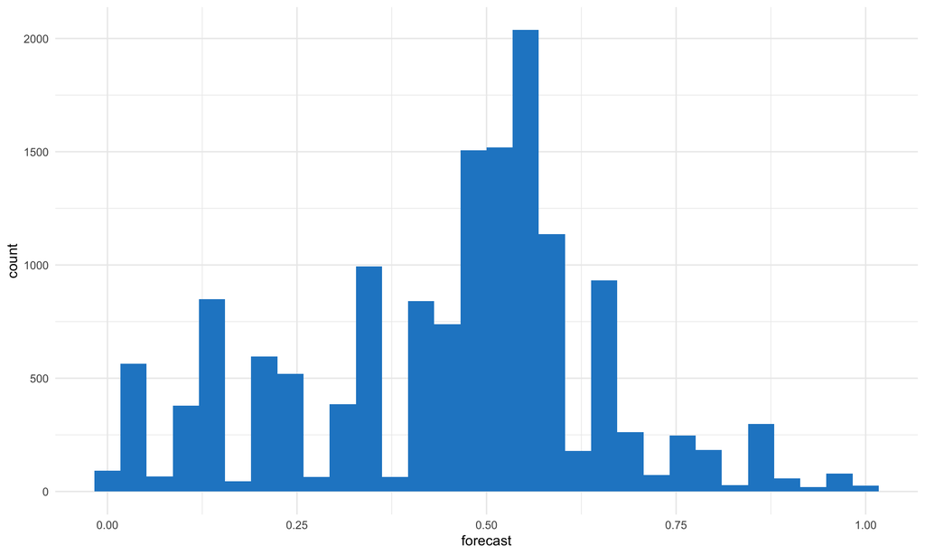

```r
combined_data %>%
  ggplot(aes(x = forecast)) +
  geom_histogram(fill="#2288cc") +
  theme_minimal()
```

## By Model

Not a huge amount of variance by model

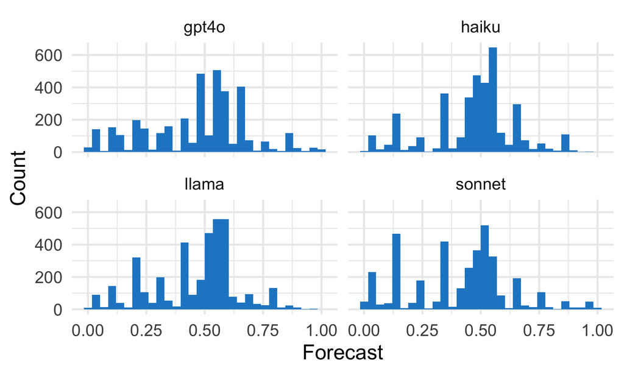

```r
combined_data %>%
  ggplot(aes(x = forecast)) +
  geom_histogram(fill="#2288cc") +
  theme_minimal(base_size=24) +
  facet_wrap(facets=vars(model)) +
  labs(
    x = "Forecast",
    y = "Count"
  )
```

```r
ggsave("figures/forecast_distribution_by_model.png", width = 12, height = 8, dpi = 300)
```

Here, mean_abs_forecast is the average distance from 0.5. Sonnet seems to produce the most decisive forecasts.

```r
combined_data %>%
  group_by(model) %>%
  summarize(
    mean_forecast = mean(forecast),
    mean_abs_forecast = mean(abs(forecast - 0.5)),
    std_forecast = sd(forecast)
  ) %>%
  arrange(-mean_abs_forecast)
```

```
## # A tibble: 4 × 4
##   model  mean_forecast mean_abs_forecast std_forecast
##   <chr>          <dbl>             <dbl>        <dbl>
## 1 sonnet         0.411             0.174        0.213
## 2 gpt4o          0.469             0.165        0.212
## 3 llama          0.460             0.144        0.186
## 4 haiku          0.473             0.127        0.177
```

## By prompt

The same aggregation by prompt. Some prompts do seem to engender more decisive forecasts.

```r
combined_data %>%
  group_by(prompt_name) %>%
  summarize(
    mean_forecast = mean(forecast),
    mean_abs_forecast = mean(abs(forecast - 0.5)),
    std_forecast = sd(forecast)
  ) %>%
  arrange(-mean_abs_forecast) %>%
  kable() %>%
  kable_styling(bootstrap_options = c("striped", "hover", "condensed"), font_size = 11)
```

| prompt_name | mean_forecast | mean_abs_forecast | std_forecast |
| --- | --- | --- | --- |
| Bayesian Reasoning | 0.4757025 | 0.1993182 | 0.2495225 |
| Propose-Evaluate-Select | 0.4696750 | 0.1746250 | 0.2243993 |
| Chain of Thought | 0.4349246 | 0.1720603 | 0.2214911 |
| Fermi Estimate | 0.4562881 | 0.1719063 | 0.2195834 |
| Superforecasting Persona (short) | 0.4533772 | 0.1707443 | 0.2173514 |
| Event Decomposition | 0.4596537 | 0.1673111 | 0.2068304 |
| Self-Critique | 0.4288220 | 0.1647906 | 0.2225076 |
| Question Paraphrasing | 0.4334422 | 0.1646482 | 0.2102259 |
| Self-Consistency | 0.4789474 | 0.1632581 | 0.2048063 |
| Time Decomposition | 0.4370231 | 0.1621821 | 0.2044560 |
| Counterfactual Reasoning | 0.4589698 | 0.1617839 | 0.2122239 |
| Tipping | 0.4580905 | 0.1600503 | 0.2125256 |
| Analogical Reasoning | 0.4583375 | 0.1597481 | 0.2033675 |
| Base Rate First | 0.4281360 | 0.1587154 | 0.2065103 |
| Uncertainty Quantification | 0.4530554 | 0.1555995 | 0.2026985 |
| Few-Shot | 0.4724242 | 0.1540909 | 0.1931463 |
| Premortem | 0.4689196 | 0.1537437 | 0.1960378 |
| Pros & Cons | 0.4479293 | 0.1524747 | 0.1909159 |
| Frequency-Based Reasoning | 0.4268667 | 0.1520133 | 0.2016797 |
| Step-Back | 0.4550779 | 0.1513090 | 0.2001526 |
| Metacognition | 0.4650508 | 0.1494670 | 0.1948096 |
| Scoring Rule | 0.4534646 | 0.1478586 | 0.1913165 |
| Abstention | 0.4487917 | 0.1472917 | 0.1927162 |
| Hypothetical Scenario Analysis | 0.4435338 | 0.1469424 | 0.1921756 |
| Deep Breath | 0.4469925 | 0.1456391 | 0.1903725 |
| Structure | 0.4509799 | 0.1429397 | 0.1894066 |
| Explicit Uncertainty Sources | 0.4578894 | 0.1417588 | 0.1830516 |
| High Personal Stakes | 0.4511267 | 0.1417052 | 0.1910166 |
| Anti-Biasing (Round Numbers) | 0.4787245 | 0.1412492 | 0.1832852 |
| Multiple Reference Classes | 0.4432619 | 0.1393722 | 0.1844219 |
| Simulated Dialogue | 0.4602105 | 0.1393684 | 0.1696837 |
| Simulated Debate | 0.4622166 | 0.1388413 | 0.1734997 |
| Echo | 0.4461616 | 0.1380303 | 0.1871773 |
| Anti-Biasing (Overconfidence). | 0.4581013 | 0.1369873 | 0.1804259 |
| Emotional Prompt | 0.4613554 | 0.1341406 | 0.1832809 |
| Control | 0.4525575 | 0.1335294 | 0.1847538 |
| Re-Reading | 0.4435459 | 0.1329337 | 0.1795089 |
| Anti-Biasing (Anchoring) | 0.4412737 | 0.1193767 | 0.1718893 |

## By Source

The betting markets and wikipedia produced the most decisive forecasts. The temp and economics ones were much closer to 0.5 which is I think what we expected.

```r
combined_data %>%
  group_by(source) %>%
  summarize(
    mean_forecast = mean(forecast),
    mean_abs_forecast = mean(abs(forecast - 0.5)),
    std_forecast = sd(forecast)
  ) %>%
  arrange(-mean_abs_forecast) %>%
  kable() %>%
  kable_styling(bootstrap_options = c("striped", "hover", "condensed"), font_size = 11)
```

| source | mean_forecast | mean_abs_forecast | std_forecast |
| --- | --- | --- | --- |
| metaculus | 0.1640079 | 0.3435380 | 0.1475511 |
| wikipedia | 0.4378611 | 0.2565447 | 0.2928119 |
| polymarket | 0.3624663 | 0.2387460 | 0.2302848 |
| manifold | 0.4482988 | 0.1947177 | 0.2163645 |
| infer | 0.3979605 | 0.1541946 | 0.1379341 |
| fred | 0.5122716 | 0.0956708 | 0.1281843 |
| yfinance | 0.5384524 | 0.0407324 | 0.0389270 |
| dbnomics | 0.4972942 | 0.0403312 | 0.0604643 |

## By question

Questions with the highest avg forecast

```r
combined_data %>%
  group_by(question) %>%
  summarize(
    mean_forecast = mean(forecast),
    mean_abs_forecast = mean(abs(forecast - 0.5)),
    std_forecast = sd(forecast)
  ) %>%
  arrange(-mean_forecast) %>%
  head(10) %>%
  kable() %>%
  kable_styling(bootstrap_options = c("striped", "hover", "condensed"), font_size = 11)
```

[output not shown]

And lowest

```r
combined_data %>%
  group_by(question) %>%
  summarize(
    mean_forecast = mean(forecast),
    mean_abs_forecast = mean(abs(forecast - 0.5)),
    std_forecast = sd(forecast)
  ) %>%
  arrange(mean_forecast) %>%
  head(10) %>%
  kable() %>%
  kable_styling(bootstrap_options = c("striped", "hover", "condensed"), font_size = 11)
```

[output not shown]

# Brier Scores

## By Model

```r
combined_data %>%
  group_by(model) %>%
  summarize(
    mean_brier_score = mean(brier_score),
    std_brier_score = sd(brier_score)
  )
```

```
## # A tibble: 4 × 3
##   model  mean_brier_score std_brier_score
##   <chr>             <dbl>           <dbl>
## 1 gpt4o             0.215           0.161
## 2 haiku             0.214           0.132
## 3 llama             0.227           0.159
## 4 sonnet            0.208           0.168
```

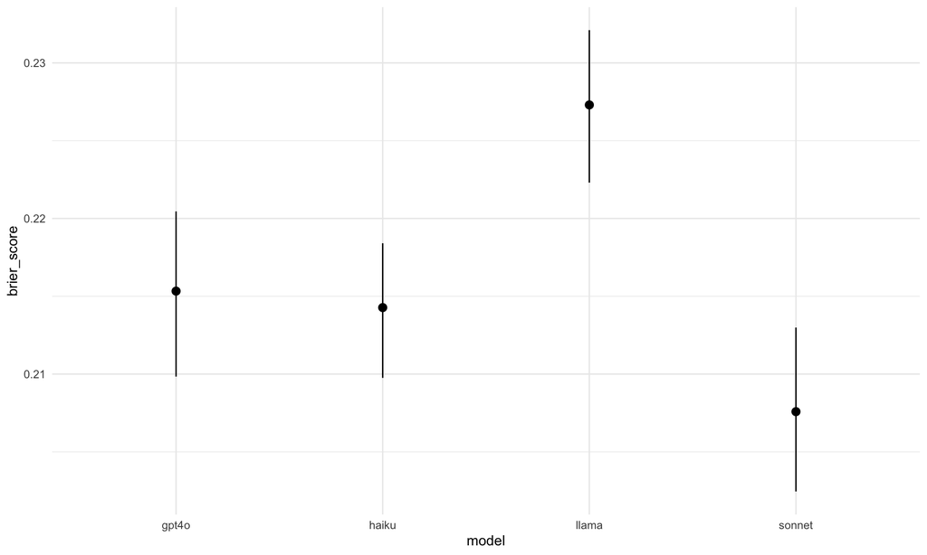

```r
combined_data %>%
  ggplot(aes(x = model, y = brier_score)) +
  stat_summary(geom="pointrange", fun.data="mean_cl_boot") +
  theme_minimal()
```

### Control prompt only

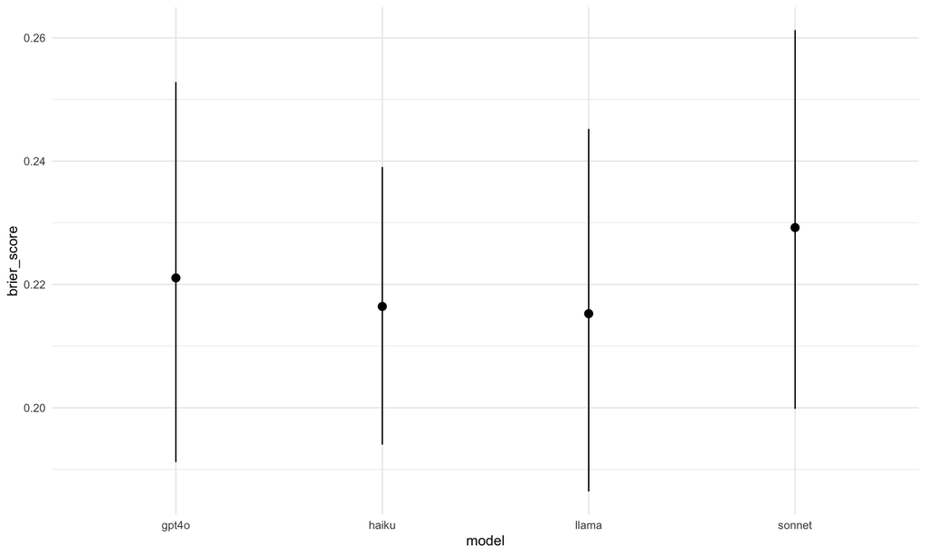

```r
combined_data %>%
  filter(prompt_id == 1) %>%
  ggplot(aes(x = model, y = brier_score)) +
  stat_summary(geom="pointrange", fun.data="mean_cl_boot") +
  theme_minimal()
```

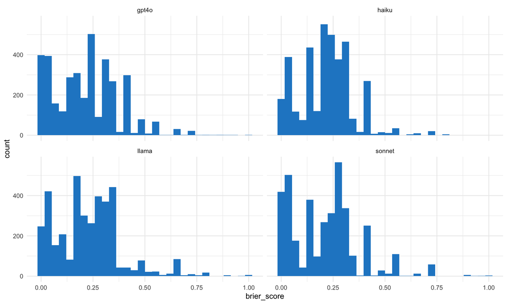

```r
combined_data %>%
  ggplot(aes(x = brier_score)) +
  geom_histogram(fill="#2288cc") +
  theme_minimal() +
  facet_wrap(facets=vars(model))
```

## By prompt

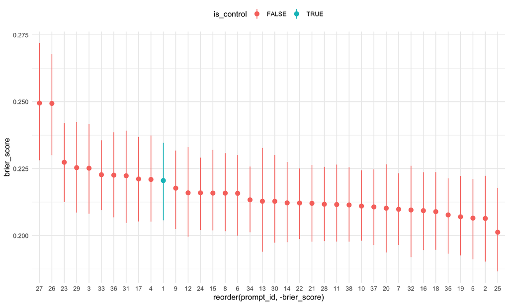

```r
combined_data %>%
  mutate(
    is_control = prompt_id == 1
  ) %>%
  ggplot(aes(x = reorder(prompt_id, -brier_score), y = brier_score, color=is_control)) +
  stat_summary(geom="pointrange", fun.data="mean_cl_boot") +
  theme_minimal() +
  theme(legend.position = "top")
```

Prompts with the lowest overall brier score

```r
combined_data %>%
  group_by(prompt_id, prompt_name) %>%
  summarize(
    mean_brier_score = mean(brier_score),
    std_brier_score = sd(brier_score)
  ) %>%
  arrange(mean_brier_score) %>%
  head(10) %>%
  kable() %>%
  kable_styling(bootstrap_options = c("striped", "hover", "condensed"), font_size = 11)
```

| prompt_id | prompt_name | mean_brier_score | std_brier_score |
| --- | --- | --- | --- |
| 25 | Frequency-Based Reasoning | 0.2012347 | 0.1455323 |
| 2 | Chain of Thought | 0.2063859 | 0.1609997 |
| 5 | Step-Back | 0.2065035 | 0.1502901 |
| 19 | Base Rate First | 0.2069982 | 0.1573046 |
| 35 | Pros & Cons | 0.2077045 | 0.1443907 |
| 18 | Premortem | 0.2089234 | 0.1453791 |
| 16 | Hypothetical Scenario Analysis | 0.2093005 | 0.1425105 |
| 32 | Question Paraphrasing | 0.2095440 | 0.1642714 |
| 7 | Echo | 0.2098152 | 0.1398748 |
| 20 | Time Decomposition | 0.2102124 | 0.1624454 |

… and the highest. These are also the only 10 that do worse than control.

```r
combined_data %>%
  group_by(prompt_id, prompt_name) %>%
  summarize(
    mean_brier_score = mean(brier_score),
    std_brier_score = sd(brier_score)
  ) %>%
  arrange(-mean_brier_score) %>%
  head(10) %>%
  kable() %>%
  kable_styling(bootstrap_options = c("striped", "hover", "condensed"), font_size = 11)
```

| prompt_id | prompt_name | mean_brier_score | std_brier_score |
| --- | --- | --- | --- |
| 27 | Bayesian Reasoning | 0.2495028 | 0.2169168 |
| 26 | Propose-Evaluate-Select | 0.2493738 | 0.1978990 |
| 23 | Anti-Biasing (Round Numbers) | 0.2273868 | 0.1467474 |
| 29 | Fermi Estimate | 0.2253596 | 0.1738496 |
| 3 | Self-Consistency | 0.2251659 | 0.1632968 |
| 33 | Simulated Dialogue | 0.2227211 | 0.1353257 |
| 36 | Event Decomposition | 0.2225697 | 0.1681125 |
| 31 | Tipping | 0.2223377 | 0.1788676 |
| 17 | Scoring Rule | 0.2211297 | 0.1553976 |
| 4 | Few-Shot | 0.2209515 | 0.1605225 |

It’s interesting that PES and Bayesian reasoning do so poorly.

We could construct post-hoc stories for why many of the top prompts do so well but I’m unsure whether they’d be justified. Overall I’m surprised by the relative lack of variance in brier score by prompt!

### Prompt by Model

There’s quite a lot of variation around how well different prompts perform for different models

```r
# Calculate prompt performance by model
prompt_by_model <- combined_data %>%
  group_by(model, prompt_id, prompt_name) %>%
  summarize(
    mean_brier = mean(brier_score, na.rm = TRUE),
    sd_brier = sd(brier_score, na.rm = TRUE),
    count = n(),
    .groups = "drop"
  )

# Get control scores for each model
control_by_model <- prompt_by_model %>%
  filter(prompt_id == 1) %>%
  select(model, control_score = mean_brier)

# Calculate improvement over control for each model
prompt_improvement <- prompt_by_model %>%
  left_join(control_by_model, by = "model") %>%
  mutate(
    improvement = control_score - mean_brier,
    percent_improvement = (improvement / control_score) * 100
  )

# Show top 5 prompts for each model
top_prompts_by_model <- prompt_improvement %>%
  group_by(model) %>%
  top_n(5, percent_improvement) %>%
  arrange(model, desc(percent_improvement))

top_prompts_by_model %>%
  select(model, prompt_id, prompt_name, mean_brier, percent_improvement) %>%
  kable() %>%
  kable_styling(bootstrap_options = c("striped", "hover", "condensed"), font_size = 11)
```

| model | prompt_id | prompt_name | mean_brier | percent_improvement |
| --- | --- | --- | --- | --- |
| gpt4o | 25 | Frequency-Based Reasoning | 0.1897054 | 14.183997 |
| gpt4o | 19 | Base Rate First | 0.1914061 | 13.414668 |
| gpt4o | 30 | Self-Critique | 0.1958455 | 11.406443 |
| gpt4o | 28 | Multiple Reference Classes | 0.1981755 | 10.352416 |
| gpt4o | 22 | Anti-Biasing (Anchoring) | 0.1990000 | 9.979438 |
| haiku | 33 | Simulated Dialogue | 0.1992195 | 7.952935 |
| haiku | 4 | Few-Shot | 0.2018495 | 6.737800 |
| haiku | 14 | Counterfactual Reasoning | 0.2019465 | 6.692992 |
| haiku | 20 | Time Decomposition | 0.2020918 | 6.625863 |
| haiku | 24 | Anti-Biasing (Overconfidence). | 0.2021794 | 6.585375 |
| llama | 5 | Step-Back | 0.2077670 | 3.481799 |
| llama | 35 | Pros & Cons | 0.2084530 | 3.163122 |
| llama | 19 | Base Rate First | 0.2086800 | 3.057669 |
| llama | 38 | Explicit Uncertainty Sources | 0.2096460 | 2.608914 |
| llama | 25 | Frequency-Based Reasoning | 0.2117298 | 1.640862 |
| sonnet | 7 | Echo | 0.1802323 | 21.371883 |
| sonnet | 37 | Deep Breath | 0.1831930 | 20.080259 |
| sonnet | 34 | Simulated Debate | 0.1872602 | 18.305901 |
| sonnet | 8 | Structure | 0.1900010 | 17.110198 |
| sonnet | 2 | Chain of Thought | 0.1914747 | 16.467265 |

```r
# Create a wide format table of Brier scores by prompt and model
prompt_performance_wide <- prompt_by_model %>%
  select(model, prompt_id, prompt_name, mean_brier) %>%
  pivot_wider(
    names_from = model,
    values_from = mean_brier
  ) %>%
  rowwise() %>%
  mutate(
    average = mean(c_across(c(gpt4o, haiku, sonnet, llama)), na.rm = TRUE),
    std_dev = sd(c_across(c(gpt4o, haiku, sonnet, llama)), na.rm = TRUE)
  ) %>%
  arrange(average) %>%
  ungroup()
```

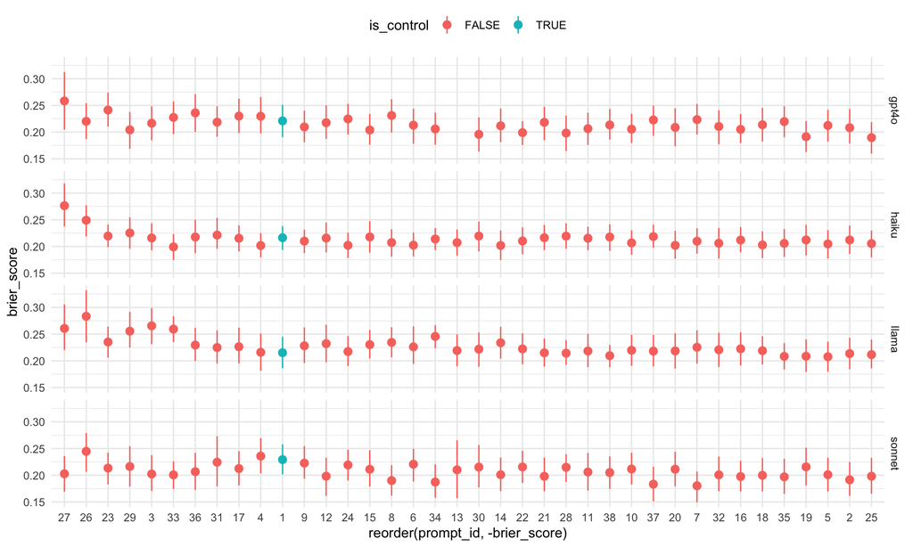

```r
combined_data %>%
  mutate(
    is_control = prompt_id == 1
  ) %>%
  ggplot(aes(x = reorder(prompt_id, -brier_score), y = brier_score, color=is_control)) +
  stat_summary(geom="pointrange", fun.data="mean_cl_boot") +
  theme_minimal() +
  theme(legend.position = "top") +
  facet_grid(rows=vars(model))
```

### Prompt Ranks by Model

This is best demonstrated by looking at average rank of prompts across models. Even the top overall prompt has an avg rank of 6.25 and the rest are 10+

```r
prompt_ranks <- prompt_by_model %>%
  group_by(model) %>%
  mutate(rank = rank(mean_brier)) %>%
  group_by(prompt_id, prompt_name) %>%
  summarize(
    avg_rank = mean(rank, na.rm = TRUE),
    std_rank = sd(rank, na.rm = TRUE),
    avg_brier = mean(mean_brier, na.rm = TRUE),
    .groups = "drop"
  ) %>%
  arrange(avg_rank)

# Show top universal prompts
prompt_ranks %>%
  top_n(10, -avg_rank) %>%
  select(prompt_id, prompt_name, avg_rank, std_rank, avg_brier) %>%
  kable() %>%
  kable_styling(bootstrap_options = c("striped", "hover", "condensed"), font_size = 11)
```

| prompt_id | prompt_name | avg_rank | std_rank | avg_brier |
| --- | --- | --- | --- | --- |
| 25 | Frequency-Based Reasoning | 6.25 | 4.112988 | 0.2012539 |
| 5 | Step-Back | 10.25 | 7.274384 | 0.2064855 |
| 2 | Chain of Thought | 10.50 | 6.454972 | 0.2063631 |
| 35 | Pros & Cons | 10.75 | 10.045729 | 0.2077331 |
| 18 | Premortem | 13.25 | 5.560276 | 0.2088856 |
| 16 | Hypothetical Scenario Analysis | 13.50 | 7.047458 | 0.2093074 |
| 20 | Time Decomposition | 13.50 | 7.767454 | 0.2101816 |
| 19 | Base Rate First | 13.75 | 13.622897 | 0.2069940 |
| 32 | Question Paraphrasing | 14.00 | 3.162278 | 0.2095131 |
| 10 | Re-Reading | 15.50 | 6.557438 | 0.2109288 |

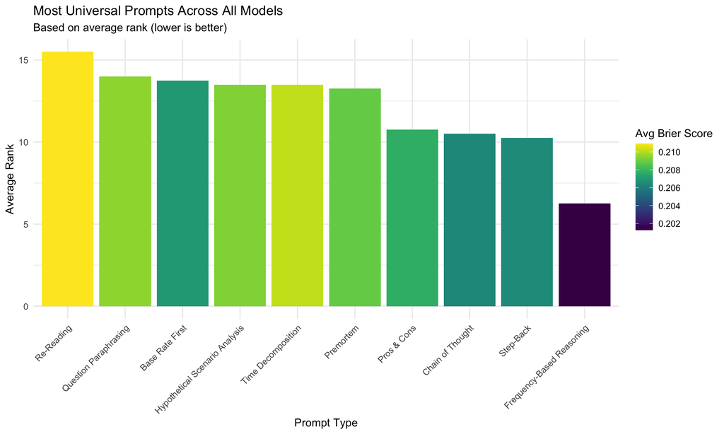

```r
# Visualize universal prompts
prompt_ranks %>%
  top_n(10, -avg_rank) %>%
  mutate(prompt_name = reorder(prompt_name, -avg_rank)) %>%
  ggplot(aes(x = prompt_name, y = avg_rank, fill = avg_brier)) +
  geom_col() +
  scale_fill_viridis() +
  labs(
    title = "Most Universal Prompts Across All Models",
    subtitle = "Based on average rank (lower is better)",
    x = "Prompt Type",
    y = "Average Rank",
    fill = "Avg Brier Score"
  ) +
  theme_minimal() +
  theme(axis.text.x = element_text(angle = 45, hjust = 1))
```

Worst prompts by average rank:

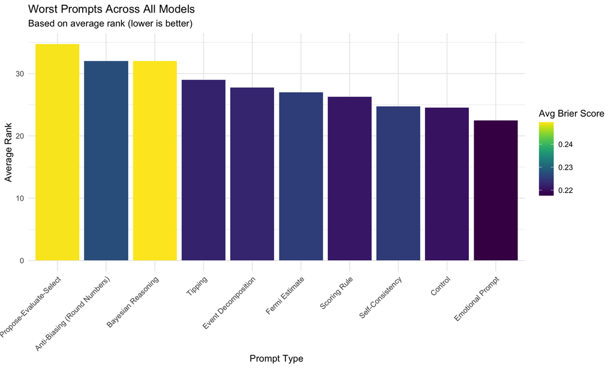

```r
# Visualize universal prompts
prompt_ranks %>%
  top_n(10, avg_rank) %>%
  mutate(prompt_name = reorder(prompt_name, -avg_rank)) %>%
  ggplot(aes(x = prompt_name, y = avg_rank, fill = avg_brier)) +
  geom_col() +
  scale_fill_viridis() +
  labs(
    title = "Worst Prompts Across All Models",
    subtitle = "Based on average rank (lower is better)",
    x = "Prompt Type",
    y = "Average Rank",
    fill = "Avg Brier Score"
  ) +
  theme_minimal() +
  theme(axis.text.x = element_text(angle = 45, hjust = 1))
```

Here are the “most consistent” prompts with the lowest sd in rank across models

```r
# Show most consistent prompts (lowest standard deviation in rank)
prompt_ranks %>%
  top_n(10, -std_rank) %>%
  arrange(std_rank) %>%
  select(prompt_id, prompt_name, avg_rank, std_rank, avg_brier) %>%
  kable() %>%
  kable_styling(bootstrap_options = c("striped", "hover", "condensed"), font_size = 11)
```

| prompt_id | prompt_name | avg_rank | std_rank | avg_brier |
| --- | --- | --- | --- | --- |
| 32 | Question Paraphrasing | 14.00000 | 3.162278 | 0.2095131 |
| 13 | Abstention | 16.66667 | 4.041452 | 0.2122312 |
| 25 | Frequency-Based Reasoning | 6.25000 | 4.112988 | 0.2012539 |
| 23 | Anti-Biasing (Round Numbers) | 32.00000 | 4.320494 | 0.2274021 |
| 17 | Scoring Rule | 26.25000 | 4.716991 | 0.2211018 |
| 11 | Uncertainty Quantification | 16.50000 | 5.507570 | 0.2115652 |
| 18 | Premortem | 13.25000 | 5.560276 | 0.2088856 |
| 26 | Propose-Evaluate-Select | 34.75000 | 5.852350 | 0.2493738 |
| 36 | Event Decomposition | 27.75000 | 6.184658 | 0.2225060 |
| 2 | Chain of Thought | 10.50000 | 6.454972 | 0.2063631 |

## By Source

```r
combined_data %>%
  group_by(source) %>%
  summarize(
    mean_brier_score = mean(brier_score),
    std_brier_score = sd(brier_score)
  ) %>%
  arrange(mean_brier_score) %>%
  kable() %>%
  kable_styling(bootstrap_options = c("striped", "hover", "condensed"), font_size = 11)
```

| source | mean_brier_score | std_brier_score |
| --- | --- | --- |
| metaculus | 0.0485748 | 0.0843547 |
| wikipedia | 0.1085476 | 0.1401057 |
| polymarket | 0.1822037 | 0.1957483 |
| infer | 0.2046783 | 0.1449765 |
| manifold | 0.2477627 | 0.2005010 |
| dbnomics | 0.2536899 | 0.0615416 |
| fred | 0.2542653 | 0.1236053 |
| yfinance | 0.2860680 | 0.0479484 |

## By Question

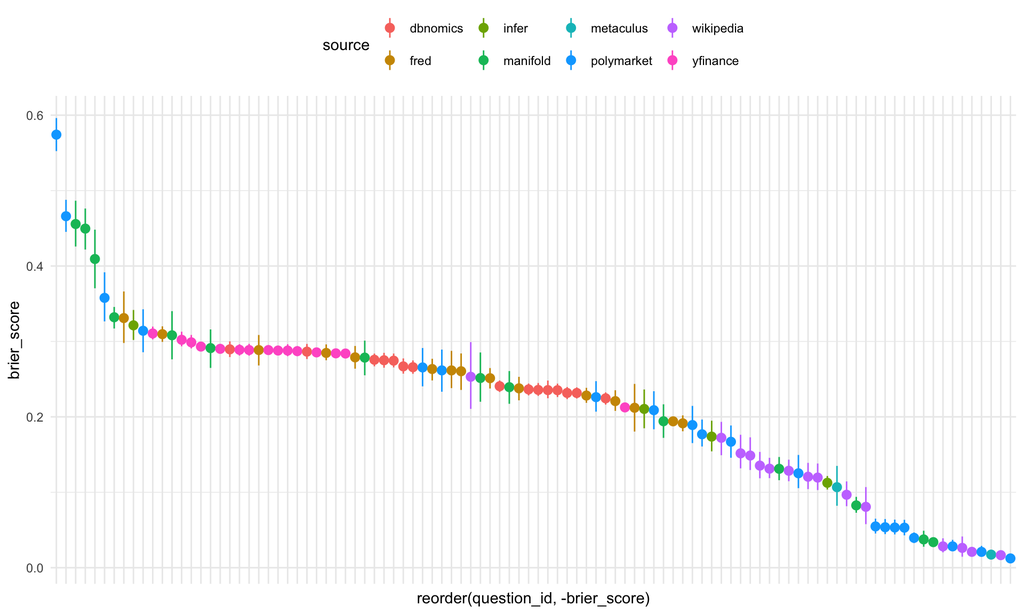

```r
combined_data %>%
  ggplot(aes(x = reorder(question_id, -brier_score), y = brier_score, color=source)) +
  stat_summary(geom="pointrange", fun.data="mean_cl_boot") +
  theme_minimal() +
  theme(legend.position = "top",
        axis.text.x = element_blank())
```

Questions with the lowest overall brier score

```r
combined_data %>%
  group_by(question, resolved_to) %>%
  summarize(
    mean_brier_score = mean(brier_score),
    std_brier_score = sd(brier_score)
  ) %>%
  arrange(mean_brier_score) %>%
  head(10) %>%
  kable() %>%
  kable_styling(bootstrap_options = c("striped", "hover", "condensed"), font_size = 11)
```

[output not shown]

… and highest

```r
combined_data %>%
  group_by(question, resolved_to) %>%
  summarize(
    mean_brier_score = mean(brier_score),
    std_brier_score = sd(brier_score)
  ) %>%
  arrange(-mean_brier_score) %>%
  head(10) %>%
  kable() %>%
  kable_styling(bootstrap_options = c("striped", "hover", "condensed"), font_size = 11)
```

[output not shown]

# “Easier” sources

Because some sources seem just hard overall I wanted to rerun some of the analyses for the ones where we might see more variance

```r
combined_data.easier <- combined_data %>%
  filter(source %in% c("metaculus", "wikipedia", "polymarket", "infer", "manifold"))
```

4o, sonnett, and haiku all do better here

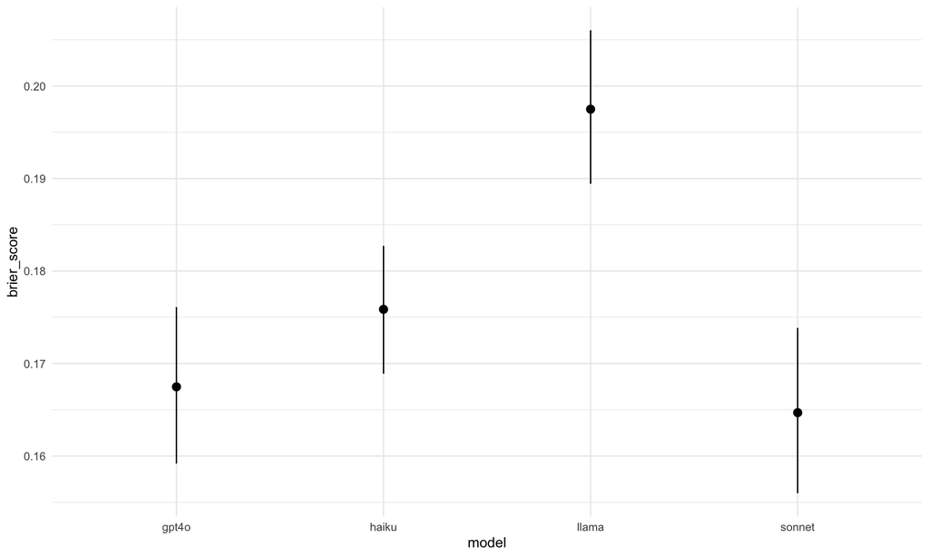

```r
combined_data.easier %>%
  ggplot(aes(x = model, y = brier_score)) +
  stat_summary(geom="pointrange", fun.data="mean_cl_boot") +
  theme_minimal()
```

Control prompt only:

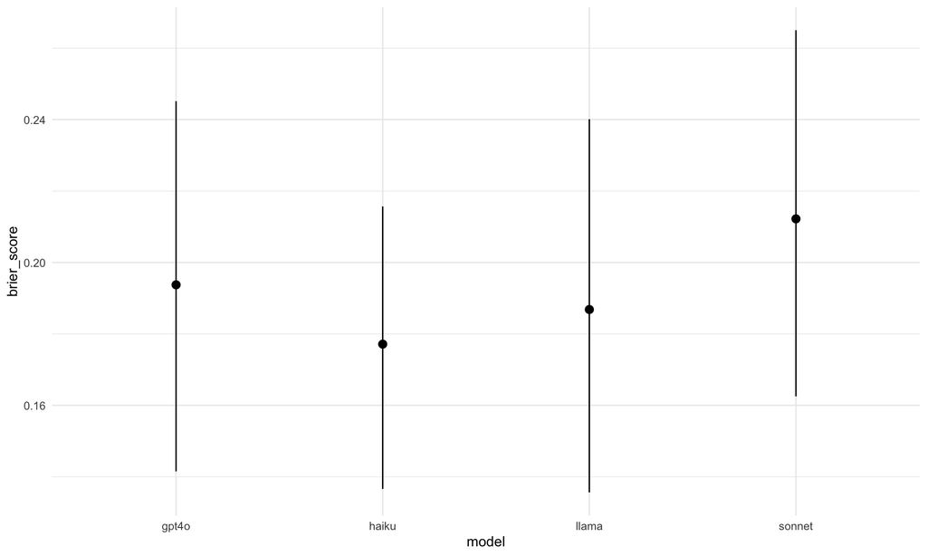

```r
combined_data.easier %>%
  filter(prompt_id == 1) %>%
  ggplot(aes(x = model, y = brier_score)) +
  stat_summary(geom="pointrange", fun.data="mean_cl_boot") +
  theme_minimal()
```

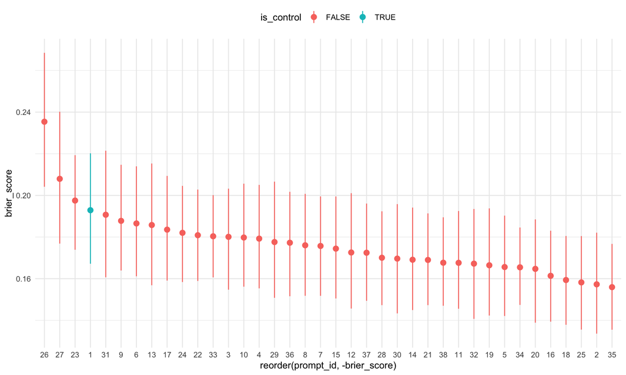

```r
combined_data.easier %>%
  mutate(
    is_control = prompt_id == 1
  ) %>%
  ggplot(aes(x = reorder(prompt_id, -brier_score), y = brier_score, color=is_control)) +
  stat_summary(geom="pointrange", fun.data="mean_cl_boot") +
  theme_minimal() +
  theme(legend.position = "top")
```

Prompts with the lowest overall brier score. Frequency, CoT and Pros & Cons again do well here.

```r
combined_data.easier %>%
  group_by(prompt_id, prompt_name) %>%
  summarize(
    mean_brier_score = mean(brier_score),
    std_brier_score = sd(brier_score)
  ) %>%
  arrange(mean_brier_score) %>%
  head(10)  %>%
  kable() %>%
  kable_styling(bootstrap_options = c("striped", "hover", "condensed"), font_size = 11)
```

| prompt_id | prompt_name | mean_brier_score | std_brier_score |
| --- | --- | --- | --- |
| 35 | Pros & Cons | 0.1559378 | 0.1618914 |
| 2 | Chain of Thought | 0.1572940 | 0.1900608 |
| 25 | Frequency-Based Reasoning | 0.1582207 | 0.1726056 |
| 18 | Premortem | 0.1593596 | 0.1659071 |
| 16 | Hypothetical Scenario Analysis | 0.1613790 | 0.1689556 |
| 20 | Time Decomposition | 0.1647168 | 0.1810123 |
| 34 | Simulated Debate | 0.1654642 | 0.1454408 |
| 5 | Step-Back | 0.1655991 | 0.1795135 |
| 19 | Base Rate First | 0.1664452 | 0.1943351 |
| 32 | Question Paraphrasing | 0.1672312 | 0.2000619 |

# Statistical Analysis

## LMER

Here we basically construct an LMER predicting diff from control on the basis of prompt_id. Then we do BH adjustment. The only significant prompts after this are the two that greatly increase Brier scores (Bayesian reasoning and PES).

```r
# 1. Calculate difference scores (experimental - control)
# First, get control scores for each model-question combination
control_scores <- combined_data %>%
  filter(prompt_id == 1) %>%
  select(model, question_id, control_brier = brier_score)

# Calculate difference scores for all data
diff_scores <- combined_data %>%
  left_join(control_scores, by = c("model", "question_id")) %>%
  mutate(
    diff_score = brier_score - control_brier,
    prompt_id = as.factor(prompt_id)) %>%
  filter(!is.na(diff_score))  # Ensure no NA values in the difference scores
```

```r
# 2. Fit linear mixed-effects model with fixed effects for prompt
# and random intercepts for model and question
mixed_model <- lmer(diff_score ~ 0 + prompt_id + (1|model) + (1|question_id),
                    data = filter(diff_scores, prompt_id != 1))
                   # data = diff_scores)  # Exclude control prompt

# Summary of the model
summary(mixed_model)
```

```
## Linear mixed model fit by REML. t-tests use Satterthwaite's method [
## lmerModLmerTest]
## Formula: diff_score ~ 0 + prompt_id + (1 | model) + (1 | question_id)
##    Data: filter(diff_scores, prompt_id != 1)
##
## REML criterion at convergence: -22086.1
##
## Scaled residuals:
##     Min      1Q  Median      3Q     Max
## -5.2496 -0.3431 -0.0199  0.3198  8.5212
##
## Random effects:
##  Groups      Name        Variance  Std.Dev.
##  question_id (Intercept) 0.0019149 0.04376
##  model       (Intercept) 0.0001822 0.01350
##  Residual                0.0117849 0.10856
## Number of obs: 14155, groups:  question_id, 100; model, 4
##
## Fixed effects:
##               Estimate Std. Error         df t value Pr(>|t|)
## prompt_id2  -0.0154372  0.0097392 12.4909087  -1.585   0.1379
## prompt_id3   0.0049286  0.0097392 12.4909087   0.506   0.6216
## prompt_id4   0.0030005  0.0097473 12.5323556   0.308   0.7633
## prompt_id5  -0.0150663  0.0097392 12.4909087  -1.547   0.1468
## prompt_id6  -0.0003271  0.0098726 13.1888883  -0.033   0.9741
## prompt_id7  -0.0104285  0.0097392 12.4909087  -1.071   0.3045
## prompt_id8  -0.0043494  0.0097392 12.4909087  -0.447   0.6628
## prompt_id9  -0.0007170  0.0098098 12.8567371  -0.073   0.9429
## prompt_id10 -0.0089240  0.0097554 12.5738958  -0.915   0.3775
## prompt_id11 -0.0099110  0.0097433 12.5118235  -1.017   0.3283
## prompt_id12 -0.0055271  0.0097473 12.5324247  -0.567   0.5807
## prompt_id13 -0.0041972  0.0107077 18.2425210  -0.392   0.6996
## prompt_id14 -0.0088461  0.0097392 12.4909087  -0.908   0.3809
## prompt_id15 -0.0064641  0.0097432 12.5114646  -0.663   0.5191
## prompt_id16 -0.0116709  0.0097392 12.4909087  -1.198   0.2530
## prompt_id17  0.0020059  0.0097432 12.5113722   0.206   0.8402
## prompt_id18 -0.0123218  0.0097392 12.4909087  -1.265   0.2289
## prompt_id19 -0.0155954  0.0097432 12.5113678  -1.601   0.1344
## prompt_id20 -0.0121999  0.0097635 12.6159071  -1.250   0.2342
## prompt_id21 -0.0092651  0.0097513 12.5527570  -0.950   0.3600
## prompt_id22 -0.0038656  0.0098366 12.9974980  -0.393   0.7007
## prompt_id23  0.0070165  0.0097473 12.5324247   0.720   0.4848
## prompt_id24 -0.0039947  0.0097433 12.5118235  -0.410   0.6887
## prompt_id25 -0.0186353  0.0098276 12.9500826  -1.896   0.0805 .
## prompt_id26  0.0287728  0.0097392 12.4909087   2.954   0.0116 *
## prompt_id27  0.0251890  0.0097512 12.5526139   2.583   0.0232 *
## prompt_id28 -0.0088141  0.0097392 12.4909087  -0.905   0.3826
## prompt_id29  0.0040385  0.0097472 12.5319089   0.414   0.6856
## prompt_id30 -0.0079169  0.0098097 12.8561655  -0.807   0.4343
## prompt_id31  0.0018633  0.0097392 12.4909087   0.191   0.8513
## prompt_id32 -0.0122847  0.0097392 12.4909087  -1.261   0.2302
## prompt_id33  0.0050949  0.0098145 12.8814346   0.519   0.6125
## prompt_id34 -0.0075131  0.0097432 12.5113755  -0.771   0.4550
## prompt_id35 -0.0131887  0.0097472 12.5319561  -1.353   0.1999
## prompt_id36  0.0023261  0.0097392 12.4909087   0.239   0.8151
## prompt_id37 -0.0091216  0.0097392 12.4909087  -0.937   0.3667
## prompt_id38 -0.0093950  0.0097392 12.4909087  -0.965   0.3530
## ---
## Signif. codes:  0 '***' 0.001 '**' 0.01 '*' 0.05 '.' 0.1 ' ' 1
```

```r
# 3. Test each prompt against zero (whether it differs from control)
prompt_tests <- emmeans(mixed_model, ~ prompt_id)
prompt_comparisons <- contrast(prompt_tests, "eff", ref = 0)  # Compare each to zero
```

```r
# 4. Apply Benjamini-Hochberg correction for multiple comparisons
prompt_results <- summary(prompt_comparisons)
prompt_results$adj.p <- p.adjust(prompt_results$p.value, method = "BH")
```

```r
# Display results sorted by estimate (negative is better than control)
prompt_results_sorted <- prompt_results %>%
  as.data.frame() %>%
  arrange(estimate)

# Join with prompt names for clearer results
prompt_names <- combined_data %>%
  select(prompt_id, prompt_name) %>%
  distinct()

final_results <- prompt_results_sorted %>%
  left_join(prompt_names %>%
              mutate(
                contrast= as.factor(paste0("prompt_id", prompt_id, " effect")
              )), by = c("contrast"))

# Display final results
final_results %>% select(prompt_name, estimate, z.ratio, p.value, adj.p)%>%
  kable() %>%
  kable_styling(bootstrap_options = c("striped", "hover", "condensed"), font_size = 11)
```

| prompt_name | estimate | z.ratio | p.value | adj.p |
| --- | --- | --- | --- | --- |
| Frequency-Based Reasoning | -0.0142639 | -2.5626469 | 0.1281158 | 0.7740439 |
| Base Rate First | -0.0112240 | -2.0691946 | 0.2534187 | 0.7740439 |
| Chain of Thought | -0.0110658 | -2.0425710 | 0.2534187 | 0.7740439 |
| Step-Back | -0.0106949 | -1.9741185 | 0.2556609 | 0.7740439 |
| Pros & Cons | -0.0088173 | -1.6234611 | 0.3866162 | 0.7740439 |
| Premortem | -0.0079504 | -1.4675264 | 0.4004836 | 0.7740439 |
| Question Paraphrasing | -0.0079133 | -1.4606812 | 0.4004836 | 0.7740439 |
| Time Decomposition | -0.0078285 | -1.4341330 | 0.4004836 | 0.7740439 |
| Hypothetical Scenario Analysis | -0.0072995 | -1.3473813 | 0.4112954 | 0.7740439 |
| Echo | -0.0060571 | -1.1180432 | 0.4875648 | 0.7740439 |
| Uncertainty Quantification | -0.0055396 | -1.0212523 | 0.5411425 | 0.7740439 |
| Explicit Uncertainty Sources | -0.0050236 | -0.9272744 | 0.5648428 | 0.7740439 |
| Metacognition | -0.0048937 | -0.8999079 | 0.5648428 | 0.7740439 |
| Deep Breath | -0.0047502 | -0.8768087 | 0.5648428 | 0.7740439 |
| Re-Reading | -0.0045526 | -0.8361181 | 0.5648428 | 0.7740439 |
| Counterfactual Reasoning | -0.0044747 | -0.8259653 | 0.5648428 | 0.7740439 |
| Multiple Reference Classes | -0.0044427 | -0.8200588 | 0.5648428 | 0.7740439 |
| Self-Critique | -0.0035455 | -0.6403186 | 0.6437575 | 0.7939675 |
| Simulated Debate | -0.0031417 | -0.5791835 | 0.6713296 | 0.8012644 |
| Analogical Reasoning | -0.0020927 | -0.3857931 | 0.8089702 | 0.9353718 |
| Superforecasting Persona (short) | -0.0011557 | -0.2127900 | 0.9322775 | 0.9967675 |
| Structure | 0.0000219 | 0.0040514 | 0.9967675 | 0.9967675 |
| Abstention | 0.0001742 | 0.0251193 | 0.9967675 | 0.9967675 |
| Anti-Biasing (Overconfidence). | 0.0003767 | 0.0694451 | 0.9967675 | 0.9967675 |
| Anti-Biasing (Anchoring) | 0.0005058 | 0.0906268 | 0.9967675 | 0.9967675 |
| Emotional Prompt | 0.0036544 | 0.6600426 | 0.6437575 | 0.7939675 |
| High Personal Stakes | 0.0040443 | 0.7169324 | 0.6255852 | 0.7939675 |
| Tipping | 0.0062347 | 1.1508359 | 0.4864521 | 0.7740439 |
| Scoring Rule | 0.0063772 | 1.1756724 | 0.4864521 | 0.7740439 |
| Event Decomposition | 0.0066975 | 1.2362619 | 0.4709039 | 0.7740439 |
| Few-Shot | 0.0073719 | 1.3573287 | 0.4112954 | 0.7740439 |
| Fermi Estimate | 0.0084099 | 1.5484486 | 0.4004836 | 0.7740439 |
| Self-Consistency | 0.0093000 | 1.7166277 | 0.3607609 | 0.7740439 |
| Simulated Dialogue | 0.0094663 | 1.7073736 | 0.3607609 | 0.7740439 |
| Anti-Biasing (Round Numbers) | 0.0113879 | 2.0967954 | 0.2534187 | 0.7740439 |
| Bayesian Reasoning | 0.0295604 | 5.4358927 | 0.0000010 | 0.0000187 |
| Propose-Evaluate-Select | 0.0331442 | 6.1179068 | 0.0000000 | 0.0000013 |

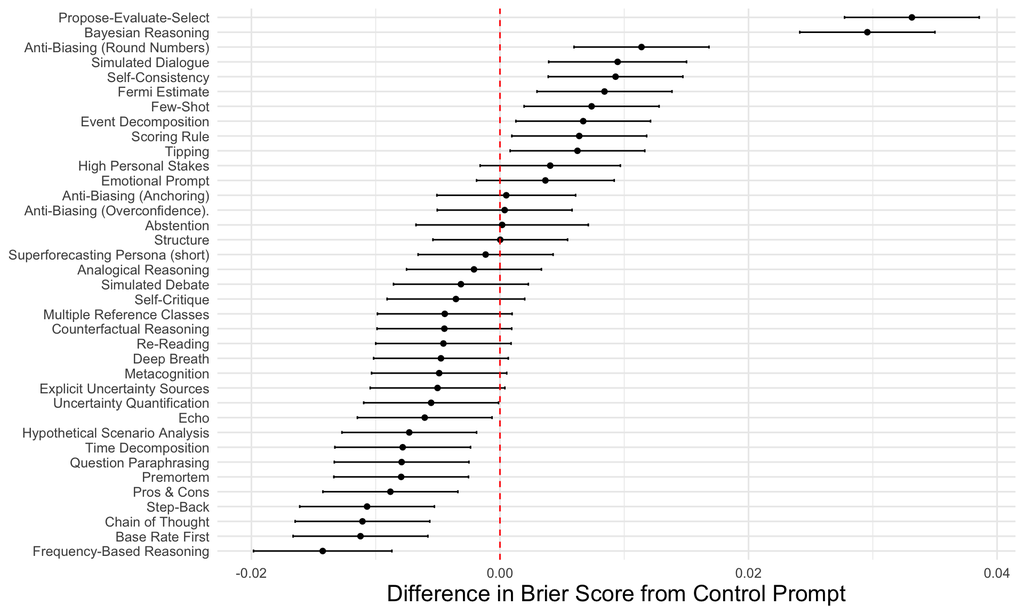

```r
# 5. Visualize the results
ggplot(final_results, aes(x = reorder(prompt_name, estimate), y = estimate)) +
  geom_point() +
  geom_errorbar(aes(ymin = estimate - SE, ymax = estimate + SE), width = 0.2) +
  geom_hline(yintercept = 0, linetype = "dashed", color = "red") +
  theme_minimal(base_size=12) +
  theme(
    axis.title.y = element_blank(),
    axis.title.x = element_text(size = 16)
  ) +
  coord_flip() +
  labs(
       y = "Difference in Brier Score from Control Prompt"
  )
```

```r
# 7. Check if any prompts are significantly better than control
sig_better <- final_results %>%
  filter(adj.p < 0.05 & estimate < 0)

# Check if any prompts are significantly worse than control
sig_worse <- final_results %>%
  filter(adj.p < 0.05 & estimate > 0)

# Print results summary
cat("\nPrompts significantly better than control (α=0.05):\n")
```

```
##
## Prompts significantly better than control (α=0.05):
```

```r
print(sig_better$prompt_name)
```

```
## character(0)
```

```r
cat("\nPrompts significantly worse than control (α=0.05):\n")
```

```
##
## Prompts significantly worse than control (α=0.05):
```

```r
print(sig_worse$prompt_name)
```

```
## [1] "Bayesian Reasoning"      "Propose-Evaluate-Select"
```

### Multiverse analysis

#### No model Intercept

```r
# and random intercepts for model and question
mixed_model <- lmer(diff_score ~ 0 + prompt_name + (1|question_id),
                    data = filter(diff_scores, prompt_id != 1))
                   # data = diff_scores)  # Exclude control prompt

# Summary of the model
summary(mixed_model)
```

```
## Linear mixed model fit by REML. t-tests use Satterthwaite's method [
## lmerModLmerTest]
## Formula: diff_score ~ 0 + prompt_name + (1 | question_id)
##    Data: filter(diff_scores, prompt_id != 1)
##
## REML criterion at convergence: -21932
##
## Scaled residuals:
##     Min      1Q  Median      3Q     Max
## -5.0653 -0.3283 -0.0337  0.3100  8.3247
##
## Random effects:
##  Groups      Name        Variance Std.Dev.
##  question_id (Intercept) 0.00193  0.04393
##  Residual                0.01192  0.10920
## Number of obs: 14155, groups:  question_id, 100
##
## Fixed effects:
##                                               Estimate Std. Error         df
## prompt_nameAbstention                       -5.207e-04  8.336e-03  1.125e+03
## prompt_nameAnalogical Reasoning             -6.307e-03  7.064e-03  5.957e+02
## prompt_nameAnti-Biasing (Anchoring)         -3.732e-03  7.193e-03  6.393e+02
## prompt_nameAnti-Biasing (Overconfidence).   -3.838e-03  7.064e-03  5.958e+02
## prompt_nameAnti-Biasing (Round Numbers)      7.175e-03  7.069e-03  5.976e+02
## prompt_nameBase Rate First                  -1.544e-02  7.064e-03  5.957e+02
## prompt_nameBayesian Reasoning                2.530e-02  7.075e-03  5.994e+02
## prompt_nameChain of Thought                 -1.528e-02  7.058e-03  5.939e+02
## prompt_nameCounterfactual Reasoning         -8.691e-03  7.058e-03  5.939e+02
## prompt_nameDeep Breath                      -8.966e-03  7.058e-03  5.939e+02
## prompt_nameEcho                             -1.027e-02  7.058e-03  5.939e+02
## prompt_nameEmotional Prompt                 -2.923e-04  7.156e-03  6.267e+02
## prompt_nameEvent Decomposition               2.482e-03  7.058e-03  5.939e+02
## prompt_nameExplicit Uncertainty Sources     -9.239e-03  7.058e-03  5.939e+02
## prompt_nameFermi Estimate                    4.151e-03  7.069e-03  5.976e+02
## prompt_nameFew-Shot                          3.202e-03  7.069e-03  5.976e+02
## prompt_nameFrequency-Based Reasoning        -1.855e-02  7.180e-03  6.350e+02
## prompt_nameHigh Personal Stakes              1.593e-04  7.243e-03  6.567e+02
## prompt_nameHypothetical Scenario Analysis   -1.152e-02  7.058e-03  5.939e+02
## prompt_nameMetacognition                    -9.023e-03  7.075e-03  5.994e+02
## prompt_nameMultiple Reference Classes       -8.659e-03  7.058e-03  5.939e+02
```

[output cut: 41 more lines]

```
## prompt_nameQuestion Paraphrasing             -1.718 0.086227 .
## prompt_nameRe-Reading                        -1.237 0.216417
## prompt_nameScoring Rule                       0.306 0.759678
## prompt_nameSelf-Consistency                   0.720 0.471610
## prompt_nameSelf-Critique                     -1.184 0.236714
## prompt_nameSimulated Debate                  -1.036 0.300791
## prompt_nameSimulated Dialogue                 0.766 0.443906
## prompt_nameStep-Back                         -2.113 0.035052 *
## prompt_nameStructure                         -0.594 0.552600
## prompt_nameSuperforecasting Persona (short)  -0.759 0.447888
## prompt_nameTime Decomposition                -1.710 0.087706 .
## prompt_nameTipping                            0.286 0.774951
## prompt_nameUncertainty Quantification        -1.381 0.167812
## ---
## Signif. codes:  0 '***' 0.001 '**' 0.01 '*' 0.05 '.' 0.1 ' ' 1
```

#### No question Intercept

```r
# and random intercepts for model and question
mixed_model <- lmer(diff_score ~ 0 + prompt_name + (1|model),
                    data = filter(diff_scores, prompt_id != 1))
                   # data = diff_scores)  # Exclude control prompt

# Summary of the model
summary(mixed_model)
```

```
## Linear mixed model fit by REML. t-tests use Satterthwaite's method [
## lmerModLmerTest]
## Formula: diff_score ~ 0 + prompt_name + (1 | model)
##    Data: filter(diff_scores, prompt_id != 1)
##
## REML criterion at convergence: -20289.1
##
## Scaled residuals:
##     Min      1Q  Median      3Q     Max
## -5.7400 -0.2589  0.0713  0.2855  8.1416
##
## Random effects:
##  Groups   Name        Variance  Std.Dev.
##  model    (Intercept) 0.0001854 0.01362
##  Residual             0.0136858 0.11699
## Number of obs: 14155, groups:  model, 4
##
## Fixed effects:
##                                               Estimate Std. Error         df
## prompt_nameAbstention                       -0.0055309  0.0102120 14.5695601
## prompt_nameAnalogical Reasoning             -0.0068789  0.0090252  8.8935517
## prompt_nameAnti-Biasing (Anchoring)         -0.0046256  0.0091410  9.3587138
## prompt_nameAnti-Biasing (Overconfidence).   -0.0044428  0.0090252  8.8934863
## prompt_nameAnti-Biasing (Round Numbers)      0.0064980  0.0090302  8.9131898
## prompt_nameBase Rate First                  -0.0159269  0.0090252  8.8934863
## prompt_nameBayesian Reasoning                0.0248575  0.0090352  8.9329938
## prompt_nameChain of Thought                 -0.0157633  0.0090202  8.8739132
## prompt_nameCounterfactual Reasoning         -0.0091722  0.0090202  8.8739132
## prompt_nameDeep Breath                      -0.0094477  0.0090202  8.8739132
## prompt_nameEcho                             -0.0107546  0.0090202  8.8739132
## prompt_nameEmotional Prompt                 -0.0006170  0.0091080  9.2242491
## prompt_nameEvent Decomposition               0.0020001  0.0090202  8.8739132
## prompt_nameExplicit Uncertainty Sources     -0.0097211  0.0090202  8.8739132
## prompt_nameFermi Estimate                    0.0035967  0.0090302  8.9131696
## prompt_nameFew-Shot                          0.0025356  0.0090302  8.9132451
## prompt_nameFrequency-Based Reasoning        -0.0193917  0.0091300  9.3136404
## prompt_nameHigh Personal Stakes             -0.0007899  0.0091859  9.5439881
## prompt_nameHypothetical Scenario Analysis   -0.0119970  0.0090202  8.8739132
## prompt_nameMetacognition                    -0.0097880  0.0090352  8.9330698
## prompt_nameMultiple Reference Classes       -0.0091402  0.0090202  8.8739132
```

[output cut: 41 more lines]

```
## prompt_nameQuestion Paraphrasing             -1.398   0.1961
## prompt_nameRe-Reading                        -1.005   0.3411
## prompt_nameScoring Rule                       0.180   0.8614
## prompt_nameSelf-Consistency                   0.510   0.6223
## prompt_nameSelf-Critique                     -0.961   0.3612
## prompt_nameSimulated Debate                  -0.878   0.4028
## prompt_nameSimulated Dialogue                 0.428   0.6787
## prompt_nameStep-Back                         -1.706   0.1226
## prompt_nameStructure                         -0.518   0.6169
## prompt_nameSuperforecasting Persona (short)  -0.669   0.5201
## prompt_nameTime Decomposition                -1.398   0.1956
## prompt_nameTipping                            0.170   0.8685
## prompt_nameUncertainty Quantification        -1.148   0.2810
## ---
## Signif. codes:  0 '***' 0.001 '**' 0.01 '*' 0.05 '.' 0.1 ' ' 1
```

#### Simple linear model

```r
# and random intercepts for model and question
mixed_model <- lm(diff_score ~ 0 + prompt_name,
                    data = filter(diff_scores, prompt_id != 1))
                   # data = diff_scores)  # Exclude control prompt

# Summary of the model
summary(mixed_model)
```

```
##
## Call:
## lm(formula = diff_score ~ 0 + prompt_name, data = filter(diff_scores,
##     prompt_id != 1))
##
## Residuals:
##      Min       1Q   Median       3Q      Max
## -0.65465 -0.02850  0.00669  0.03300  0.93631
##
## Coefficients:
##                                               Estimate Std. Error t value
## prompt_nameAbstention                       -0.0019151  0.0076225  -0.251
## prompt_nameAnalogical Reasoning             -0.0068277  0.0059546  -1.147
## prompt_nameAnti-Biasing (Anchoring)         -0.0045940  0.0061301  -0.749
## prompt_nameAnti-Biasing (Overconfidence).   -0.0043918  0.0059546  -0.738
## prompt_nameAnti-Biasing (Round Numbers)      0.0065501  0.0059623   1.099
## prompt_nameBase Rate First                  -0.0158759  0.0059546  -2.666
## prompt_nameBayesian Reasoning                0.0248662  0.0059700   4.165
## prompt_nameChain of Thought                 -0.0157133  0.0059470  -2.642
## prompt_nameCounterfactual Reasoning         -0.0091223  0.0059470  -1.534
## prompt_nameDeep Breath                      -0.0093977  0.0059470  -1.580
## prompt_nameEcho                             -0.0107046  0.0059470  -1.800
## prompt_nameEmotional Prompt                 -0.0003038  0.0060807  -0.050
## prompt_nameEvent Decomposition               0.0020500  0.0059470   0.345
## prompt_nameExplicit Uncertainty Sources     -0.0096711  0.0059470  -1.626
## prompt_nameFermi Estimate                    0.0036044  0.0059623   0.605
## prompt_nameFew-Shot                          0.0026283  0.0059623   0.441
## prompt_nameFrequency-Based Reasoning        -0.0194089  0.0061135  -3.175
## prompt_nameHigh Personal Stakes             -0.0004062  0.0061978  -0.066
## prompt_nameHypothetical Scenario Analysis   -0.0119471  0.0059470  -2.009
## prompt_nameMetacognition                    -0.0096536  0.0059700  -1.617
## prompt_nameMultiple Reference Classes       -0.0090903  0.0059470  -1.529
## prompt_namePremortem                        -0.0125980  0.0059470  -2.118
## prompt_namePropose-Evaluate-Select           0.0284967  0.0059470   4.792
## prompt_namePros & Cons                      -0.0135895  0.0059623  -2.279
## prompt_nameQuestion Paraphrasing            -0.0125609  0.0059470  -2.112
## prompt_nameRe-Reading                       -0.0090339  0.0059777  -1.511
## prompt_nameScoring Rule                      0.0016732  0.0059546   0.281
## prompt_nameSelf-Consistency                  0.0046524  0.0059470   0.782
## prompt_nameSelf-Critique                    -0.0094193  0.0060807  -1.549
```

[output cut: 37 more lines]

```
## prompt_nameSelf-Critique                     0.12139
## prompt_nameSimulated Debate                  0.18820
## prompt_nameSimulated Dialogue                0.49278
## prompt_nameStep-Back                         0.00989 **
## prompt_nameStructure                         0.43670
## prompt_nameSuperforecasting Persona (short)  0.31480
## prompt_nameTime Decomposition                0.03427 *
## prompt_nameTipping                           0.78956
## prompt_nameUncertainty Quantification        0.08346 .
## ---
## Signif. codes:  0 '***' 0.001 '**' 0.01 '*' 0.05 '.' 0.1 ' ' 1
##
## Residual standard error: 0.1176 on 14118 degrees of freedom
## Multiple R-squared:  0.008854,   Adjusted R-squared:  0.006256
## F-statistic: 3.409 on 37 and 14118 DF,  p-value: 1.366e-11
```

## T-tests

With the simpler t-tests, we see signif results for 3 prompts:

```r
# 6. Secondary analysis: one-sample t-tests for each prompt
t_test_results <- diff_scores %>%
  filter(prompt_id != 1) %>%
  group_by(prompt_id, prompt_name) %>%
  summarize(
    mean_diff = mean(diff_score),
    sd_diff = sd(diff_score),
    n = n(),
    t_stat = t.test(diff_score)$statistic,
    p_value = t.test(diff_score)$p.value,
    .groups = "drop"
  ) %>%
  mutate(adj_p_value = p.adjust(p_value, method = "BH")) %>%
  arrange(mean_diff)


# Display t-test results
t_test_results %>%
  kable() %>%
  kable_styling(bootstrap_options = c("striped", "hover", "condensed"), font_size = 11)
```

| prompt_id | prompt_name | mean_diff | sd_diff | n | t_stat | p_value | adj_p_value |
| --- | --- | --- | --- | --- | --- | --- | --- |
| 25 | Frequency-Based Reasoning | -0.0194089 | 0.1142755 | 370 | -3.2669882 | 0.0011889 | 0.0219942 |
| 19 | Base Rate First | -0.0158759 | 0.1055388 | 390 | -2.9706968 | 0.0031556 | 0.0356679 |
| 2 | Chain of Thought | -0.0157133 | 0.1277864 | 391 | -2.4314825 | 0.0154867 | 0.0856085 |
| 5 | Step-Back | -0.0153425 | 0.1070086 | 391 | -2.8350751 | 0.0048200 | 0.0356679 |
| 35 | Pros & Cons | -0.0135895 | 0.1109832 | 389 | -2.4150142 | 0.0161962 | 0.0856085 |
| 20 | Time Decomposition | -0.0126882 | 0.1493525 | 385 | -1.6669288 | 0.0963439 | 0.2096897 |
| 18 | Premortem | -0.0125980 | 0.1059417 | 391 | -2.3513730 | 0.0192011 | 0.0888052 |
| 32 | Question Paraphrasing | -0.0125609 | 0.1267255 | 391 | -1.9599455 | 0.0507139 | 0.1461517 |
| 16 | Hypothetical Scenario Analysis | -0.0119471 | 0.1067416 | 391 | -2.2131756 | 0.0274638 | 0.1126862 |
| 7 | Echo | -0.0107046 | 0.0974528 | 391 | -2.1720245 | 0.0304557 | 0.1126862 |
| 11 | Uncertainty Quantification | -0.0103081 | 0.1159792 | 390 | -1.7552184 | 0.0800091 | 0.1850210 |
| 38 | Explicit Uncertainty Sources | -0.0096711 | 0.1017892 | 391 | -1.8787217 | 0.0610282 | 0.1505361 |
| 21 | Metacognition | -0.0096536 | 0.0989196 | 388 | -1.9223092 | 0.0553007 | 0.1461517 |
| 30 | Self-Critique | -0.0094193 | 0.1408038 | 374 | -1.2937123 | 0.1965653 | 0.3463294 |
| 37 | Deep Breath | -0.0093977 | 0.0918988 | 391 | -2.0220888 | 0.0438494 | 0.1461517 |
| 14 | Counterfactual Reasoning | -0.0091223 | 0.1263968 | 391 | -1.4270996 | 0.1543513 | 0.3005788 |
| 28 | Multiple Reference Classes | -0.0090903 | 0.1132134 | 391 | -1.5876923 | 0.1131663 | 0.2326196 |
| 10 | Re-Reading | -0.0090339 | 0.0915656 | 387 | -1.9408675 | 0.0530020 | 0.1461517 |
| 34 | Simulated Debate | -0.0078362 | 0.1471128 | 390 | -1.0519249 | 0.2934870 | 0.4282771 |
| 15 | Analogical Reasoning | -0.0068277 | 0.1255549 | 390 | -1.0739219 | 0.2835234 | 0.4282771 |
| 12 | Superforecasting Persona (short) | -0.0059936 | 0.1141282 | 389 | -1.0357766 | 0.3009515 | 0.4282771 |
| 8 | Structure | -0.0046256 | 0.1014384 | 391 | -0.9016789 | 0.3677840 | 0.5040003 |
| 22 | Anti-Biasing (Anchoring) | -0.0045940 | 0.0764568 | 368 | -1.1526584 | 0.2498008 | 0.4018535 |
| 24 | Anti-Biasing (Overconfidence). | -0.0043918 | 0.0698974 | 390 | -1.2408322 | 0.2154155 | 0.3622898 |
| 13 | Abstention | -0.0019151 | 0.0890117 | 238 | -0.3319242 | 0.7402399 | 0.8175227 |
| 6 | High Personal Stakes | -0.0004062 | 0.0917811 | 360 | -0.0839698 | 0.9331273 | 0.9487271 |
| 9 | Emotional Prompt | -0.0003038 | 0.0913172 | 374 | -0.0643486 | 0.9487271 | 0.9487271 |
| 31 | Tipping | 0.0015872 | 0.1368735 | 391 | 0.2293000 | 0.8187559 | 0.8655420 |
| 17 | Scoring Rule | 0.0016732 | 0.0973505 | 390 | 0.3394214 | 0.7344755 | 0.8175227 |
| 36 | Event Decomposition | 0.0020500 | 0.1277814 | 391 | 0.3172324 | 0.7512370 | 0.8175227 |
| 4 | Few-Shot | 0.0026283 | 0.1099665 | 389 | 0.4713958 | 0.6376231 | 0.7673235 |
| 29 | Fermi Estimate | 0.0036044 | 0.1532035 | 389 | 0.4640213 | 0.6428927 | 0.7673235 |
| 33 | Simulated Dialogue | 0.0041764 | 0.1346012 | 373 | 0.5992504 | 0.5493707 | 0.7009213 |
| 3 | Self-Consistency | 0.0046524 | 0.1386774 | 391 | 0.6633801 | 0.5074790 | 0.6705973 |
| 23 | Anti-Biasing (Round Numbers) | 0.0065501 | 0.0923777 | 389 | 1.3984683 | 0.1627712 | 0.3011268 |
| 27 | Bayesian Reasoning | 0.0248662 | 0.1715953 | 388 | 2.8544358 | 0.0045433 | 0.0356679 |
| 26 | Propose-Evaluate-Select | 0.0284967 | 0.1528934 | 391 | 3.6854774 | 0.0002606 | 0.0096409 |

```r
# 7. Check if any prompts are significantly better than control
sig_better <- t_test_results %>%
  filter(adj_p_value < 0.05 & mean_diff < 0)

# Check if any prompts are significantly worse than control
sig_worse <- t_test_results %>%
  filter(adj_p_value < 0.05 & mean_diff > 0)

# Print results summary
cat("\nPrompts significantly better than control (α=0.05):\n")
```

```
##
## Prompts significantly better than control (α=0.05):
```

```r
print(sig_better$prompt_name)
```

```
## [1] "Frequency-Based Reasoning" "Base Rate First"
## [3] "Step-Back"
```

```r
cat("\nPrompts significantly worse than control (α=0.05):\n")
```

```
##
## Prompts significantly worse than control (α=0.05):
```

```r
print(sig_worse$prompt_name)
```

```
## [1] "Bayesian Reasoning"      "Propose-Evaluate-Select"
```